# Turismo de Cultura

Principales indicadores para caracterizar los viajes y el perfil de las y los viajeros, nacionales y extranjeros, que realizan Turismo de Cultura en Argentina.

# Presentación

Con la reciente publicación del [Informe de Naturaleza](https://tableros.yvera.tur.ar/institucional/turismo-naturaleza/informe_tur_nat.pdf), la [Dirección Nacional de Mercados y Estadística del Ministerio de Turismo y Deportes de la Nación](https://www.yvera.tur.ar/sinta/) inaugura una secuencia de documentos con el objetivo de caracterizar a los diferentes perfiles turísticos que se desarrollan en Argentina. En esta oportunidad, se pone a disposición el informe de [**Turismo de Cultura**](https://tableros.yvera.tur.ar/institucional/turismo-cultura/informe_cultura.pdf), un conjunto de estadísticas relacionadas con las **prácticas turísticas en entornos culturales**.

> [**Acceso al informe**](https://tableros.yvera.tur.ar/institucional/turismo-cultura/informe_cultura.pdf)

Las principales fuentes de información con la que se elaboró el informe, sea para el turismo nacional como el internacional, son:

- La **Encuesta de Viajes y Turismo de los Hogares (EVyTH)**, a partir de la cual se releva información sociodemográfica de los residentes en argentina y de las principales caraceterísticas de sus viajes.
- La **Encuesta de Turismo Internacional (ETI)**, en donde se indaga sobre los principales aspectos de las y los viajeros residentes en el exterior.

### ¿Qué se entiende por Turismo de Cultura?

Según la Organización Mundial del Turismo

> *El turismo cultural es un tipo de actividad turística en el que la motivación esencial del visitante es aprender, descubrir, disfrutar y consumir los atractivos/productos materiales e inmateriales de un destino turístico. Estos atractivos/productos guardan relación con un conjunto de elementos materiales, intelectuales, espirituales y emocionales distintivos de una sociedad, entre ellos las artes y la arquitectura, el patrimonio histórico y cultural, el patrimonio gastronómico, la literatura, la música, las industrias creativas y las culturas vivas, con sus estilos de vida, sistemas de valores, creencias y tradiciones.* [^1]

En base a esta definición y con las fuentes disponibles, se elaboró la siguiente operacionalización:

**Según la ETI, se pueden consideran las siguientes actividades:**

- Actividades culturales en lugares urbanos.
- Asistencia a eventos deportivos o culturales.
- Actividades de tango.
- Actividades vinculadas al vino.
- Actividades vinculadas con la gastronomía.

**Según la EVyTH, se consideran las siguientes actividades:**

- Asistencia a actos o festividades religiosas.
- Visitas a teatros, cines, conciertos o recitales.
- Visitas a museos, monumentos, parques temáticos, zoológicos, etc.
- Asistencia a espectáculos deportivos.

# Principales resultados

## TURISMO INTERNACIONAL

### PARTICIPACIÓN ANUAL DE LOS TURISTAS QUE REALIZARON TURISMO DE CULTURA DURANTE SU VIAJE POR ARGENTINA

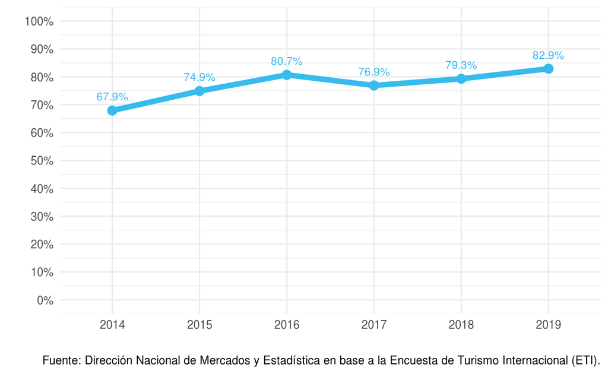

**PERFIL DEL TURISMO DE CULTURA - AÑO 2019**

Estadía y gasto promedio

| **Variable:** | **Total Turistas** | **Turistas de cultura** |
| --- | --- | --- |
| Estadía promedio en la Argentina (en noches) | 12,0 | 11,4 |
| Gasto por turista (en US$) | 925,7 | 906,2 |
| Gasto promedio diario (en US$) | 77,3 | 79,6 |

**Fuente:** Dirección Nacional de Mercados y Estadística en base a la Encuesta de Turismo Internacional (ETI).

### GASTO PROMEDIO POR TURISTA EN USD (2015-2019)

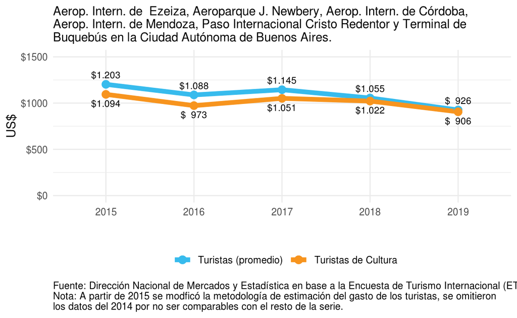

## TURISMO NACIONAL

### PARTICIPACIÓN ANUAL DE LOS TURISTAS QUE REALIZARON TURISMO DE CULTURA DURANTE SU VIAJE POR ARGENTINA

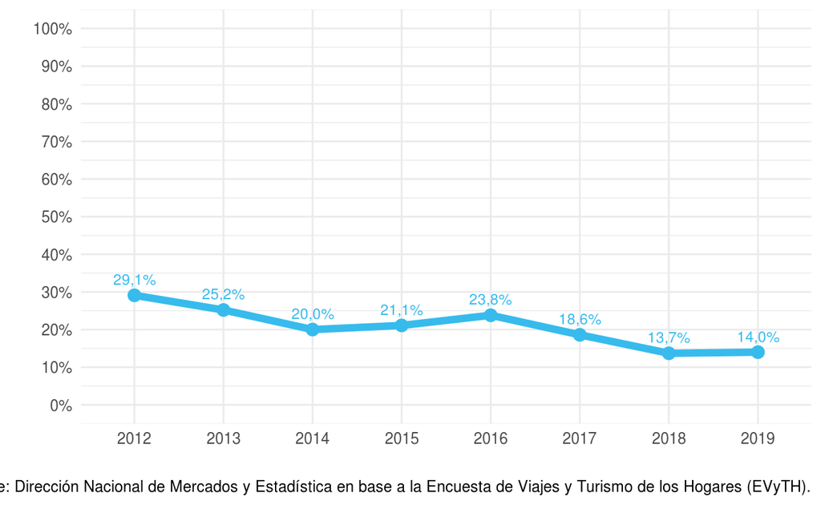

### PRINCIPALES REGIONES ELEGIDAS PARA REALIZAR TURISMO. AÑO 2019

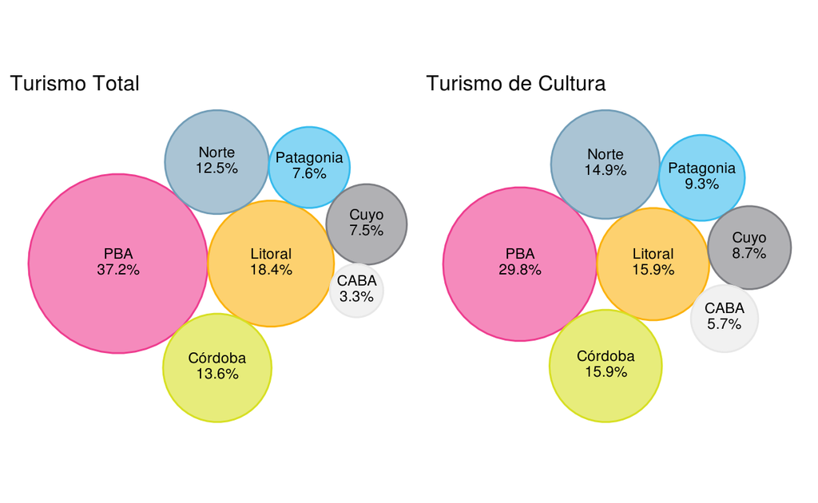

**Estadía y gasto***

|  | **Turistas Totales** Estadía media | **Turistas Totales** Gasto diario | **Turistas de Cultura** Estadía media | **Turistas de Cultura** Gasto diario |
| --- | --- | --- | --- | --- |
| 2012 | 5,6 | $3.741 | 7,4 | $3.739 |
| 2013 | 5,7 | $3.552 | 7,1 | $4.114 |
| 2014 | 5,4 | $3.694 | 7,4 | $4.106 |
| 2015 | 6,2 | $3.557 | 7,7 | $4.475 |
| 2016 | 5,9 | $3.256 | 7,6 | $3.974 |
| 2017 | 5,4 | $3.175 | 6,4 | $4.092 |
| 2018 | 5,3 | $2.930 | 6,6 | $3.922 |
| 2019 | 5,3 | $2.846 | 6,7 | $3.634 |

* Gasto en $ constante en pesos de febrero 2022 (IPC Turístico)

[^1]: (https://www.unwto.org/es/etica-cultura-y-responsabilidad-social)